# French Bakery Sales

Rachelle Cha

2022-12-12

```r
#read csv

bakery <- read.csv("/Users/rachellecha/Desktop/data101/bakery.csv")
```

## This is data from a French Bakery Sales.

```r
#format the date
library(lubridate)
bakery$date <- ymd(bakery$date)
```

### lets see what kind of items are being sold

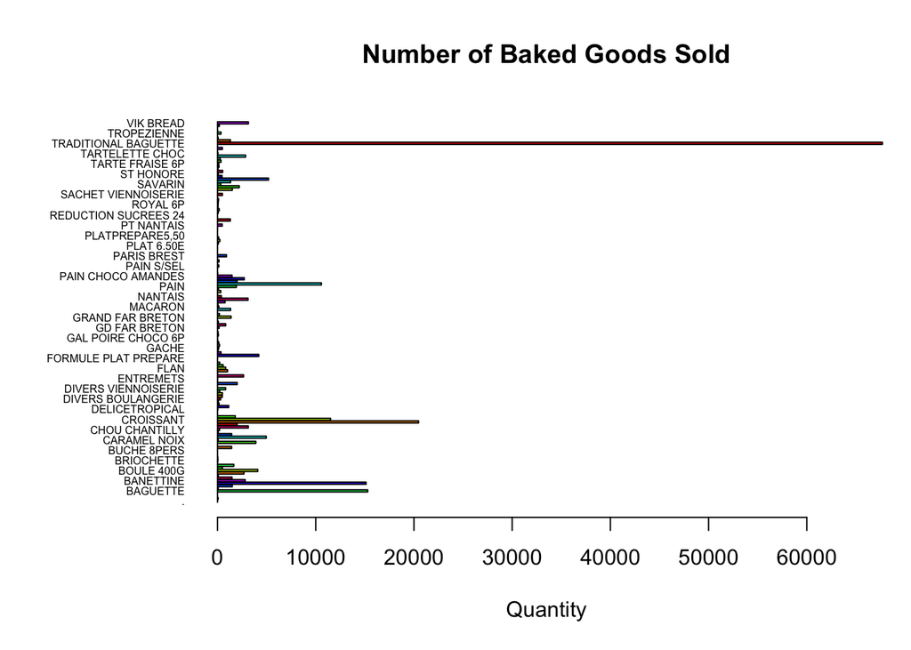

```r
par(mar=c(5,8,4,1)+.1)
barplot(table(bakery$article),col=rainbow(10), las=1, horiz=TRUE, cex.names=0.5, main = "Number of Baked Goods Sold", xlab="Quantity")
```

Based on this graph, we can see that the bakery sells many different types of bread. We can see that the most popular bread is the Traditional Baguette. Lets diver a little closer into it

### We will subset the data to only include rows where the Traditional Baguette is being sold.

```r
bakery_baguette <- bakery[bakery$article == "TRADITIONAL BAGUETTE", ]
```

### lets see when people usually buy traditional baguettes

#### plotting the data

```r
library(tidyverse)
```

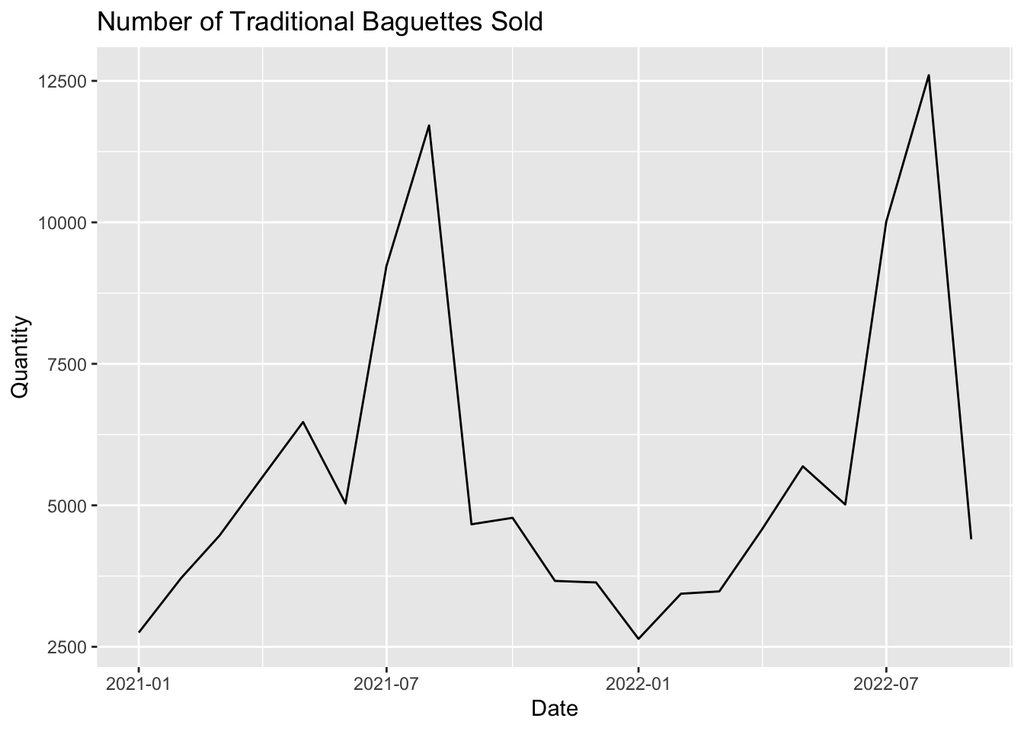

```r
library(ggplot2)

#group by month then plot
bakery_baguette %>%
    group_by(month = lubridate::floor_date(date, 'month')) %>%
    summarize(sum = sum(Quantity)) %>%
    ggplot(aes(month, sum)) +
    geom_line() +
    ggtitle("Number of Traditional Baguettes Sold") +
    xlab("Date") +
    ylab("Quantity")
```

As we can see It seems that people really like to buy Traditional Baguettes during the summer months! People seem to like Baguettes! This information is important because then the baker can know to prepare more baguettes in the summer. I wonder what the average number of baguettes a person buys in a single trip is? Since Baguettes are big, I bet the average person only buys 1 at a time.

## Hypothesis Testing

### null hypothesis: people buy one baguette (x = 1)

### alternative hypothesis: people don’t buy one baguette (x != 1)

#### alpha = 0.05

```r
mu <- mean(bakery_baguette$Quantity)

x <- 1

n <- length(bakery_baguette$Quantity)

std <- sd(bakery_baguette$Quantity)

z <- (x-mu)/(std/sqrt(n))

print(z)
```

```
## [1] -159.8403
```

```r
p_val <- pnorm(z)*2

print(p_val)
```

```
## [1] 0
```